[figure not shown]

# FACTORES ASOCIADOS CON LA DURACIÓN DE LACTANCIA MATERNA EXCLUSIVA

Análise por Guilherme Pichok

Método: o teste de x² foi utilizado para verificar a dependência entre as variáveis das hipóteses.

## Perguntas a responder

### I. Características gerais da coleta

*As informações desse bloco visam caracterizar e informar se todas as entrevistas seguiram os padrões estabelecidos pelos pesquisadores.*

1. Qual foi o período de coleta? *(min, max)*
2. Quantas mães foram entrevistadas? *(total)*
3. Todas as mães assinaram o TCI? *(sim/nao; freq)*
4. Quantas mães entrevistaram cada pesquisador? *(pesquisador; freq)*
5. Todas as mães entrevistadas cumpriram com os criterios de inclusão e exclusão? *(sim/nao; freq)*

### II. Características das mães

*As informações desse bloco visam caracterizar a população entrevistada. Alguma dessas características está relacionada com a duração da LME?*

1. Qual a **idade** mínima, máxima e média? *(min, max; grafico: distribuição)*
2. Qual a **idade** dos RNs por frequencia? *(tabela + grafico: freq)*
3. Qual a **formação acadêmica** por frequencia? *(tabela + grafico: freq)*
4. Qual o **estado civil** por frequencia? *(tabela + grafico: freq)*
5. Qual o **número de filhos** por frequencia? *(tabela + grafico: freq)*
6. Quantas já **amamentaram**? *(tabela + grafico: freq)*
7. Qual a **vía de parto** por frequencia? *(tabela + grafico: freq)*
8. Periodo de amamentação de fihos anteriores (excusivo, predominante, mixto) *(tabela: freq)*

### III. Informações sobre amamentação materna exclusiva

*As informações desse bloco visam saber as características e qualidade das orientações recebidas. Alguma dessas características está relacionada com a duração da LME?*

1. **Recebeu** alguma informação?
2. **Onde** foi informada?
3. **Quem** informou?
4. **Quais foram** as informações obtidas?

### IV. Conhecimento acerca da amamentação

*As informações desse bloco visam identificar o conhecimento das mães acerca da LME. Um maior conhecimento acerca da LME está relacionado com uma maior duração da LME?*

1. Quando se deveria iniciar a amamentação materna?
2. Qual seria a duração adequada da amamentação materna exclusiva?
3. Qual seria a duração adequada da amamentação?

### V. Hábitos

1. Está amamentando exclusivamente com leite?
2. (21 negativa) Qual foi o motivo da pausa?
3. Se utiliza leite artifical. quem aconselhou?
4. Quando amamentou pela primeira vez?
5. Teve ajuda na primeira vez?
6. Quem ajudou?
7. Teve lactancia mixta?
8. O qsentiu?
9. Outro leite?
10. Como outro leite?
11. Chupeta na sala do parto?
12. Agora usa chupeta?

### VI. Problemas durante a amamentação

1. Sabe identificar sinais de agarre?
2. Quais informações
3. Como amamenta o filho?
4. Sabe identificar rachaduras?
5. Chegou a apresentar sinais inflamatorios?
6. Durante a amamentação teve algum desses problemas?
7. Como classifica o mamilo?
8. Sentiu dor?
9. de 1 a 10?
10. Quando a dor desapareceu?
11. Teve ajuda adequada?
12. Voveria a repetir a experiencia?

[figure not shown]

### Configurando ambiente

Importando bibliotecas e banco de dados...

```python
import pandas as pd
import numpy as np
import matplotlib.pyplot as plt
import matplotlib.dates as mdates
from matplotlib.ticker import MaxNLocator
# Teste Qui-Quadrado
from scipy.stats import chi2_contingency
import scipy.stats as stats
```

```python
csv_url = 'https://docs.google.com/spreadsheets/d/e/2PACX-1vTzAUa_23-IUJgA_0-v2Xj8HjG7w6eKJyUldJLSdgUeS3XEjecpZ4vSk-vEkgqTJH22cZEaqNKHMZR4/pub?gid=267148281&single=true&output=csv'
```

Reescrevendo nomes das colunas...

```python
df = pd.read_csv(csv_url)
df = df.rename(
    columns = {
        #Características gerais do questionário
        'Timestamp': 'Data',
        '¿Firmó el consentimiento informado?': 'Consentimento',
        'Encuestador': 'Pesquisador',
        '¿Cumple los criterios de inclusión y exclusión?': 'Criterios',
        'Edad\nIdade': 'Idade_mae',
        'Edad del RN\nIdade do RN': 'Idade_rn',
        'Formación académica\nFormação acadêmica': 'Formacao_academica',
        'Estado civil': 'Estado_civil',
        'Número de hijos (incluyendo el actual)\nNúmero de filhos (incluindo o atual)': 'N_filhos',
        '¿Ha amantado anteriormente?\nJá amamentou anteriormente?': 'Amamentacao_previa',
        '¿Tuvo su último hijo por parto vaginal o por cesárea?\nTeve seu último filho por parto vaginal ou cesárea?': 'Via_parto',
        'Contacto\nContato': 'Contato',
        '1º Hijo / Filho [Exclusivo (solo leche materna)]': '1_exclusivo',
        '1º Hijo / Filho [Predominante (leche materna y agua o té)]': '1_predominante',
        '1º Hijo / Filho [Mixto (leche materna y leche artificial o papilla y sopas)]': '1_mixto',
        '2º Hijo / Filho [Exclusivo (solo leche materna)]': '2_exclusivo',
        '2º Hijo / Filho [Predominante (leche materna y agua o té)]': '2_predominante',
        '2º Hijo / Filho [Mixto (leche materna y leche artificial o papilla y sopas)]': '2_mixto',
        '3º Hijo / Filho [Exclusivo (solo leche materna)]': '3_exclusivo',
        '3º Hijo / Filho [Predominante (leche materna y agua o té)]': '3_predominante',
        '3º Hijo / Filho [Mixto (leche materna y leche artificial o papilla y sopas)]': '3_mixto',
        '4º Hijo / Filho [Exclusivo (solo leche materna)]': '4_exclusivo',
        '4º Hijo / Filho [Predominante (leche materna y agua o té)]': '4_predominante',
        '4º Hijo / Filho [Mixto (leche materna y leche artificial o papilla y sopas)]': '4_mixto',
        #Informações
        '¿Fuiste informada sobre la lactancia materna durante su embarazo?\nRecebeu alguma informação sobre a amamentação materna durante a gravidez?': 'Recebeu_informacao',
        '¿Dónde fuiste informada? \nOnde foi informada?': 'Onde_informacao',
        '¿Quién le informó sobre la lactancia?  \nQuem te informou sobre a amamentação?': 'Quem_informacao',
        'Las informaciones obtenidas fueron:\nAs informações obtidas foram:': 'Quais_informacoes',
        #Conhecimentos
        '¿Cuándo se debe iniciar la lactancia materna?\nQuando se deve iniciar a amamentação materna?': 'Inicio_LME',
        '¿Cuál es la duración adecuada de la lactancia materna exclusiva (dar SÓLO leche materna)?\nQual é a duração adequada da amamentação materna exclusiva (dar SOMENTE leite materno)': 'Duracao_LME',
        '¿Cuál es la duración adecuada de la lactancia materna (dar leche materna y otros alimentos)?\nQual a duração adequada da amamentação materna (dar leite materno E outros alimentos)': 'Duracao_LMx',
        #Hábitos
        '¿Estás amamantando exclusivamente con leche materna en este momento?\nEstá amamentando exclusivamente com leite materno nesse momento?': 'Esta_amamentando',
        'Si la respuesta es negativa. ¿Por qué dejaste de amantar?\nSe a resposta é negativa. Por que deixou de amamentar?': 'Motivo_interrupcao',
        'Si la respuesta es negativa. ¿Cuándo dejó de amamantar? (en meses)\nSe a resposta é negativa. Quando deixou de amamentar? (em meses)': 'Quando_interrompeu',
        'Si utiliza leche artificial. ¿Quién aconsejó introducir leche artificial? \nSe utiliza leite artificial. Quem aconselhou introduzir leite artificial?': 'Quem_indicou_leite_artificial',
        '¿Cuándo le amamantó por primera vez? \nQuando amamentou pela primeira vez?': 'Quando_amamentou_primeira_vez',
        ' ¿Tuviste ayuda con la primera toma?\nTeve ajuda na primeira vez?': 'Teve_ajuda_primeira_vez',
        'Si la respuesta es positiva. ¿Quién ayudó? \nSe a resposta é positiva. Quem ajudou?': 'Quem_ajudou_primeira_vez',
        '¿Su bebe tuvo lactancia mixta (materna + fórmula)? \nSeu bebê teve amamentação mixta? (materna + fórmula)': 'Amamentacao_mixta',
        '¿Qué sentiste la primera vez que amamantaste, cumplió con tus expectativas?\nO que sentiu a primeira vez que amamentou, alcançou suas expectativas?': 'Expectativa',
        '¿Le dieron a su hijo otra leche en el hospital?\nDeram a seu filho outro leite no hospital? ': 'Outro_leite',
        '¿Cómo le administraron la leche?  \nComo lhe deram o leite?': 'Como_outro_leite',
        '¿Le ofrecieron un chupete al bebé en la sala de maternidad?  \nOfereceram-lhe uma chupeta ao bebê na sala de maternidade?': 'Chupeta_maternidade',
        '¿Ahora tu hijo usa chupete?  \nAgora, seu filho usa chupeta?': 'Chupeta_agora',
        #Problemas durante a amamentação
        '¿Cuándo el bebé está amamantando, sabes identificar los signos de agarre correcta?  \nQuando o bebê está mamando, sabe identificar os sinais de agarre correto?': 'Sabe_identificar_agarre_correto',
        'Seleccione las afirmaciones correctas sobre los signos de agarre correcto:\nSelecione as afirmações corretas sobre os sinais de agarre correto:': 'Sinais_agarre_correto',
        'Marcar como amamanta su hijo:  \nMarcar como amamenta seu filho:': 'Como_amamenta',
        '¿Puedo (Sabes) identificar grietas del pezón en la mama?\nPosso (Sabe) identificar rachaduras no mamilo do seio?': 'Rachaduras',
        '¿Llegó a presentar signos inflamatorios en la mama?\nChegou a apresentar sinais inflamatórios na mama?': 'Sinais_inflamatorios',
        '¿Durante la lactancia tuve alguno de estos problemas?  \nDurante a amamentação teve algum desses problemas? ': 'Problemas',
        '¿Como clasifica su pezón? \nComo classifica seu mamilo?': 'Mamilo',
        '¿Durante alguna vez en la lactancia sintió dolor con las mamadas? \nDurante a amamentação, alguma vez sentiu dor?': 'Dor',
        'Se si, en una escala de 1-10 como clasifica el dolor?\nSe sim, em uma escala de 1-10 como classifica a dor?': 'Dor_escala',
        '¿Cuándo el dolor se desapareció?  \nQuando a dor desapareceu?': 'Dor_desapareceu',
        '¿Recibí ayuda adecuada cuando tuve dificultades en la lactancia?\nRecebeu ajuda adequada quando teve dificuldades na amamentação?': 'Recebeu_ajuda',
        '¿Fue la lactancia una experiencia que volverias a reptir con otro hijo? \nA amamentação foi uma experiência que voltaria a repetir com outro filho?': 'Repetiria',
        'Observações': 'OBS'
    }
)
```

Verificando informações do DataFrame...

```python
df['Formacao_academica'] = df['Formacao_academica'].str.split(' / ').str[0]
df['Problemas'] = df['Problemas'].str.split(' / ').str[0]
df['Onde_informacao'] = df['Onde_informacao'].str.split(' / ').str[0]
df.head()
```

|  | Data | Consentimento | Pesquisador | Criterios | Idade_mae | Idade_rn | Formacao_academica | Estado_civil | N_filhos | Amamentacao_previa | ... | Rachaduras | Sinais_inflamatorios | Problemas | Mamilo | Dor | Dor_escala | Dor_desapareceu | Recebeu_ajuda | Repetiria | OBS |
| --- | --- | --- | --- | --- | --- | --- | --- | --- | --- | --- | --- | --- | --- | --- | --- | --- | --- | --- | --- | --- | --- |
| 0 | 8/15/2024 10:38:14 | Sí | Igor | Sí | 25 | 3 | Enseñanza secundaria (15 a 17 años) | Unión estable | 9 | Sí | ... | No | No | NaN | Pseudo invertido | Sí | 10.0 | Nao desapareceu | No | No | 9 filhos (5to, 6to, 7mo, 8vo filho amamentaçao... |
| 1 | 8/22/2024 9:30:52 | Sí | Anna | Sí | 24 | 5 | Educación básica (6 a 14 años) | Soltera | 3 | Sí | ... | No | No | No | Normal | Sí | 3.0 | Dismiunui solamente | Sí | Sí | NaN |
| 2 | 8/22/2024 9:39:48 | Sí | Lívia | Sí | 31 | 1 | Enseñanza secundaria (15 a 17 años) | Soltera | 2 | Sí | ... | Sí | No | Grieta en el pezón | Normal | Sí | 6.0 | 10 dias | Sí | Sí | NaN |
| 3 | 8/22/2024 10:49:51 | Sí | Anna | Sí | 34 | 1 | Educación básica (6 a 14 años) | Soltera | 2 | Sí | ... | No | No | No | Normal | No | NaN | NaN | Sí | Sí | NaN |
| 4 | 8/22/2024 11:02:59 | Sí | Lívia | Sí | 16 | 6 | Educación básica (6 a 14 años) | Soltera | 1 | No | ... | No | No | Solo pega um lado da mama | Normal | No | NaN | NaN | Sí | Sí | NaN |

5 rows × 57 columns

```python
df.info()
```

```
<class 'pandas.core.frame.DataFrame'>
RangeIndex: 60 entries, 0 to 59
Data columns (total 57 columns):
 #   Column                           Non-Null Count  Dtype
---  ------                           --------------  -----
 0   Data                             60 non-null     object
 1   Consentimento                    60 non-null     object
 2   Pesquisador                      60 non-null     object
 3   Criterios                        60 non-null     object
 4   Idade_mae                        60 non-null     int64
 5   Idade_rn                         60 non-null     int64
 6   Formacao_academica               60 non-null     object
 7   Estado_civil                     60 non-null     object
 8   N_filhos                         60 non-null     int64
 9   Amamentacao_previa               60 non-null     object
```

[output cut: 49 more lines]

Definindo funções...

```python
def qui_quadrado(df, var1, var2, traducao=False):
    # Remover os registros ausentes de SEXO, TIPO_PARTO
    df2 = df[[var1,var2]].dropna(how = 'any', subset=[var1, var2])

    if traducao:
        df2[var1] = df2[var1].str.split(' / ').str[0]

    tabAbsoluto = pd.crosstab(df2[var1], df2[var2])
    tabRelativo = pd.crosstab(df2[var1], df2[var2], normalize=True)

    #print(df[var1].str.split(', ').explode().value_counts())

    tabela_combined = tabAbsoluto.astype(str) + ' (' + (tabRelativo * 100).round(2).astype(str) + '%)'


    tabela_combined.loc['Total'] = tabAbsoluto.sum().astype(str) + ' (' + (tabRelativo.sum() * 100).round(2).astype(str) + '%)'
    tabela_combined['Total'] = tabAbsoluto.sum(axis=1).astype(str) + ' (' + (tabRelativo.sum(axis=1) * 100).round(2).astype(str) + '%)'

    tabela_combined.at['Total', 'Total'] = tabAbsoluto.sum().sum().astype(str) + ' (' + (tabRelativo.sum().sum()* 100).round(2).astype(str) + '%)'

    # Calculando o qui-quadrado
    stat, p, dof, expected = stats.chi2_contingency(tabAbsoluto)

    print(f'Valor P: {p:.3f}')

    return tabela_combined
```

[figure not shown]

## Análise

### I. Características gerais da coleta

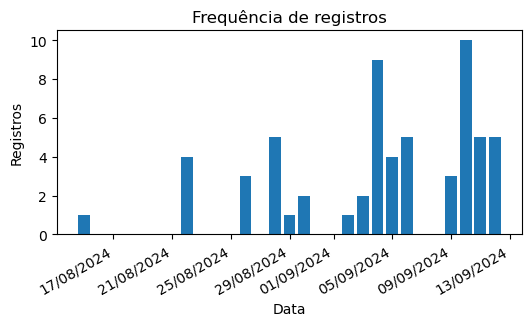

```python
datas_freq = pd.to_datetime(df['Data']).dt.date.value_counts().sort_index(ascending=True)
datas_freq = pd.DataFrame(datas_freq)
data_max = datas_freq.index.max()
data_min = datas_freq.index.min()
todas_datas = pd.date_range(start=data_min, end=data_max, normalize=True)
todas_datas = pd.DataFrame({
    'datas': todas_datas
}).set_index('datas')
todas_datas['valores'] = datas_freq

# Criar um gráfico de barras
plt.figure(figsize=(6, 3))
plt.bar(todas_datas.index, todas_datas['valores'])

# Formatar o eixo x para mostrar apenas a data
plt.gca().xaxis.set_major_formatter(mdates.DateFormatter('%d/%m/%Y'))

# Rotacionar as datas para melhor visualização
plt.gcf().autofmt_xdate()

# Adicionar título e rótulos
plt.title('Frequência de registros')
plt.xlabel('Data')
plt.ylabel('Registros')

# Exibir o gráfico
plt.show()
```

#### 1. Qual foi o período de coleta? (min, max)

```python
# Escreva a resposta
print('>> O período de coleta foi de ' + data_min.strftime("%d/%m/%Y") + ' até ' + data_max.strftime("%d/%m/%Y"))
```

```
>> O período de coleta foi de 15/08/2024 até 12/09/2024
```

#### 2. Quantas mães foram entrevistadas? E de que nacionalidade eram?

```python
print('>> ' + np.array2string(df['Data'].count()) + ' mães foram entrevistadas.')
py = ['Anna', 'Lívia']
resul_py = df[df['Pesquisador'].isin(py)]
count_py = ['Paraguay', resul_py['Data'].count()]
result_br = df[~df['Pesquisador'].isin(py)]
count_br = ['Brasil', result_br['Data'].count()]
resutados_br_py = [count_py, count_br]
resutados_br_py
```

```
>> 60 mães foram entrevistadas.
```

```
[['Paraguay', 9], ['Brasil', 51]]
```

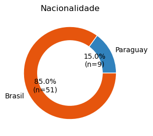

```python
fig, ax = plt.subplots(figsize=(6, 3))

size = 0.3
vals = np.array([[ 9, 51]])

cmap = plt.colormaps["tab20c"]
outer_colors = cmap(np.arange(3)*4)
inner_colors = cmap([1, 2, 5, 6, 9, 10])

def func(pct, allvals):
    absolute = int(np.round(pct/100.*np.sum(allvals)))
    return f"{pct:.1f}%\n(n={absolute:d})"

wedges, texts, autotexts = ax.pie(vals.flatten(), radius=1, colors=outer_colors,
        labels=['Paraguay', 'Brasil'],
       #pctdistance=.5, labeldistance=.5,
       #autopct='%1.1f%%',
       autopct=lambda pct: func(pct, vals),
       wedgeprops=dict(width=size, edgecolor='w'))

#ax.legend(wedges, ['Paraguay', 'Brasil'], loc="center left", bbox_to_anchor=(1, 0, 0.5, 1))

#ax.pie(vals.flatten(), radius=1-size, colors=inner_colors, labels=['Paraguay', 'Brasil'], autopct='%1.1f%%',
       #wedgeprops=dict(width=size, edgecolor='w'))

ax.set(aspect="equal", title='Nacionalidade')
plt.show()
```

#### 3. Todas as mães assinaram o TCI?

```python
todas_sim = (df['Consentimento'] == 'Sí').all()
tci_si = (df['Consentimento'] == 'Sí').sum()
tci_no = (df['Consentimento'] == 'No').sum()
if todas_sim:
    print(f">> Sim. Todas as {tci_si} assinaram o Termo de Consentimento Informado")
else:
    print(f">> Não. Entre as {tci_si + tci_no}, {tci_no} não assinaram Termo de Consentimento Informado")
```

[output not shown]

#### 4. Quantas mães entrevistaram cada pesquisador?

```
Fábio        20
Guilherme    10
Ayla          9
Igor          8
Anna          7
Lívia         2
Nathalia      2
Júlia         2
Name: Pesquisador, dtype: int64
```

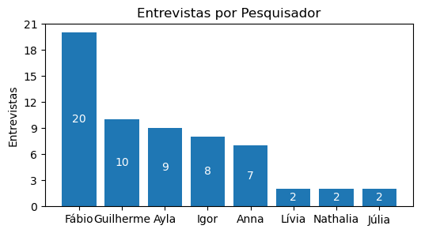

```python
pesq_keys = df['Pesquisador'].value_counts().keys()
pesq_values = df['Pesquisador'].value_counts().values

fig, ax = plt.subplots(figsize=(6,3))
bar_container = ax.bar(pesq_keys, pesq_values)
ax.set(ylabel='Entrevistas', title='Entrevistas por Pesquisador')
ax.bar_label(bar_container, fmt='{:,.0f}', label_type='center', color='w')
ax.yaxis.set_major_locator(MaxNLocator(integer=True))

df['Pesquisador'].value_counts()
```

#### 5. Todas as mães entrevistadas cumpriram com os criterios de inclusão e exclusão?

```python
todos_criterios_sim = (df['Criterios'] == 'Sí').all()
criterios_si = (df['Criterios'] == 'Sí').sum()
criterios_no = (df['Criterios'] == 'No').sum()
if todos_criterios_sim:
    print(f">> Sim. Todas as {criterios_si} cumpriram com os critérios de inclusão e exclusão.")
else:
    print(f">> Não. Entre as {criterios_si + criterios_no}, {criterios_no} não cumpriram com os critérios de inclusão e exclusão.")
```

[output not shown]

[figure not shown]

### II. Características das mães

#### 6. Qual a **idade** mínima, máxima e média das mães entrevistadas?

```python
print(f">> A idade mínima das mães entrevistadas foi de {df['Idade_mae'].min()} anos.")
print(f">> A idade máxima das mães entrevistadas foi de {df['Idade_mae'].max()} anos.")
print(f">> A idade média das mães entrevistadas foi de {df['Idade_mae'].mean().round(2)} anos.")
```

```
>> A idade mínima das mães entrevistadas foi de 14 anos.
>> A idade máxima das mães entrevistadas foi de 41 anos.
>> A idade média das mães entrevistadas foi de 26.95 anos.
```

#### 7. Qual a **idade** dos RNs por frequencia?

```
   Idade do RN (em meses)  Frequência
0                       6          15
2                       5           9
4                       4           8
1                       3          12
5                       2           6
3                       1           8
6                       0           2
```

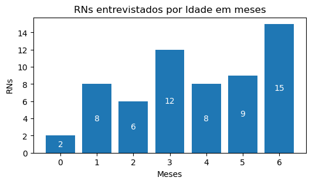

```python
idades_rn = pd.DataFrame(df['Idade_rn'])

# Criar a tabela de frequência
idades_rn_frq = df['Idade_rn'].value_counts().reset_index()
idades_rn_frq.columns = ['Idade do RN (em meses)', 'Frequência']
idades_rn_frq = idades_rn_frq.sort_values(by='Idade do RN (em meses)',ascending=False)

# Exibir a tabela de frequência
print(idades_rn_frq)

# Criar um gráfico de barra
pesq_keys = df['Idade_rn'].value_counts().keys()
pesq_values = df['Idade_rn'].value_counts().values

fig, ax = plt.subplots(figsize=(6,3))
bar_container = ax.bar(pesq_keys, pesq_values)
ax.set(ylabel='RNs', xlabel='Meses', title='RNs entrevistados por Idade em meses')
ax.bar_label(bar_container, fmt='{:,.0f}', label_type='center', color='w')
ax.yaxis.set_major_locator(MaxNLocator(integer=True))
```

#### 8. Qual a **formação acadêmica** das mães por frequência?

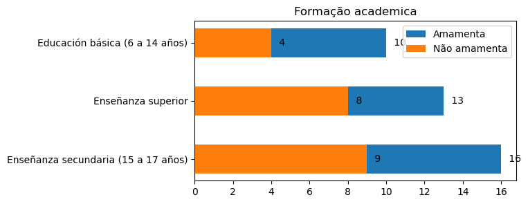

```python
idades_rn = pd.DataFrame(df['Formacao_academica'])

# Criar um gráfico de barra
pesq_keys = df['Formacao_academica'].value_counts().keys()
pesq_values = df['Formacao_academica'].value_counts().values

gugu_liberato = {
    #todas, brasi paraguay p/ cada valor
    "Amamenta": np.array([]),
    "Não amamenta": np.array([])
}
gugu_legend = []
for form in pesq_keys:
    #amamenta
    #todas
    gugu_legend.append(form)
    lme_tds = df.loc[(df['Esta_amamentando'] =='Si') & (df['Formacao_academica'] == form), ['Formacao_academica','Esta_amamentando','Pesquisador']]

    #br
    #lme_br = df.loc[(df['Esta_amamentando'] =='Si') & ~((df['Pesquisador'] =='Lívia') | (df['Pesquisador'] =='Anna')), ['Formacao_academica','Esta_amamentando','Pesquisador']]
    #py
    #lme_py = df.loc[(df['Esta_amamentando'] =='Si') & ((df['Pesquisador'] =='Lívia') | (df['Pesquisador'] =='Anna')), ['Formacao_academica','Esta_amamentando','Pesquisador']]

    #n amamenta
    #todas
    n_lme_tds = df.loc[~(df['Esta_amamentando'] =='Si') & (df['Formacao_academica'] == form), ['Formacao_academica','Esta_amamentando','Pesquisador']]
    #br
    #n_lme_br = df.loc[~(df['Esta_amamentando'] =='Si') & ~((df['Pesquisador'] =='Lívia') | (df['Pesquisador'] =='Anna')), ['Formacao_academica','Esta_amamentando','Pesquisador']]
    #py
    #n_lme_py = df.loc[~(df['Esta_amamentando'] =='Si') & ((df['Pesquisador'] =='Lívia') | (df['Pesquisador'] =='Anna')), ['Formacao_academica','Esta_amamentando','Pesquisador']]

    #adiciona ao gugu
    gugu_liberato['Amamenta'] = np.append(gugu_liberato['Amamenta'], lme_tds.shape[0])
    #gugu_liberato['Amamenta'] = np.append(gugu_liberato['Amamenta'], lme_br.shape[0])
    #gugu_liberato['Amamenta'] = np.append(gugu_liberato['Amamenta'], lme_py.shape[0])
    gugu_liberato['Não amamenta'] = np.append(gugu_liberato['Não amamenta'], n_lme_tds.shape[0])
    #gugu_liberato['Não amamenta'] = np.append(gugu_liberato['Não amamenta'], lme_br.shape[0])
    #gugu_liberato['Não amamenta'] = np.append(gugu_liberato['Não amamenta'], lme_py.shape[0])

gugu_liberato
# Criar gráfico composto com tres barras 1=todas; 2=brasil; 3=paraguay. e divididas por amamentando e nao amamentando

width = 0.5

fig, ax = plt.subplots(figsize=(6,3))
bottom = np.zeros(3)

for boolean, gugu_liberato in gugu_liberato.items():
    p = ax.barh(gugu_legend, gugu_liberato, width, label=boolean)
    ax.bar_label(p, fmt=' {:,.0f}', label_type='edge', color='0', padding=5)

ax.set_title("Formação academica")
ax.legend(loc="upper right")

plt.show()

#qui_quadrado(df, 'Formacao_academica', 'Esta_amamentando')
```

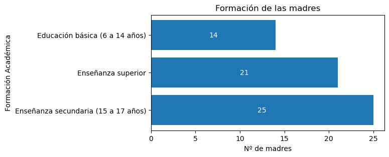

```python
fig, ax = plt.subplots(figsize=(6,3))
bar_container = ax.barh(pesq_keys, pesq_values)
ax.set(ylabel='Formación Académica', xlabel='Nº de madres', title='Formación de las madres')
ax.bar_label(bar_container, fmt='{:,.0f}', label_type='center', color='w')
ax.yaxis.set_major_locator(MaxNLocator(integer=True))
```

[output not shown]

[figure not shown]

#### 9. Qual o **estado civil** por frequencia?

```python
qui_quadrado(df, 'Estado_civil', 'Esta_amamentando')
```

```
Valor P: 0.485
```

| Esta_amamentando Estado_civil | No | Si | Total |
| --- | --- | --- | --- |
| Casada | 2 (3.64%) | 5 (9.09%) | 7 (12.73%) |
| Separada | 1 (1.82%) | 3 (5.45%) | 4 (7.27%) |
| Soltera | 2 (3.64%) | 8 (14.55%) | 10 (18.18%) |
| Unión estable | 15 (27.27%) | 19 (34.55%) | 34 (61.82%) |
| Total | 20 (36.36%) | 35 (63.64%) | 55 (100.0%) |

#### 10. Qual o **número de filhos** por frequencia?

```python
qui_quadrado(df, 'N_filhos', 'Esta_amamentando')
```

```
Valor P: 0.450
```

| Esta_amamentando N_filhos | No | Si | Total |
| --- | --- | --- | --- |
| 1 | 14 (25.45%) | 17 (30.91%) | 31 (56.36%) |
| 2 | 4 (7.27%) | 6 (10.91%) | 10 (18.18%) |
| 3 | 2 (3.64%) | 7 (12.73%) | 9 (16.36%) |
| 4 | 0 (0.0%) | 3 (5.45%) | 3 (5.45%) |
| 5 | 0 (0.0%) | 1 (1.82%) | 1 (1.82%) |
| 9 | 0 (0.0%) | 1 (1.82%) | 1 (1.82%) |
| Total | 20 (36.36%) | 35 (63.64%) | 55 (100.0%) |

#### 11. Quantas já **amamentaram**?

```python
qui_quadrado(df, 'Amamentacao_previa', 'Esta_amamentando')
```

```
Valor P: 0.145
```

| Esta_amamentando Amamentacao_previa | No | Si | Total |
| --- | --- | --- | --- |
| No | 14 (25.45%) | 16 (29.09%) | 30 (54.55%) |
| Sí | 6 (10.91%) | 19 (34.55%) | 25 (45.45%) |
| Total | 20 (36.36%) | 35 (63.64%) | 55 (100.0%) |

#### 12. Qual a **vía de parto** por frequencia?

```python
qui_quadrado(df, 'Via_parto', 'Esta_amamentando')
```

```
Valor P: 0.055
```

| Esta_amamentando Via_parto | No | Si | Total |
| --- | --- | --- | --- |
| Cesárea | 13 (23.64%) | 12 (21.82%) | 25 (45.45%) |
| Parto vaginal | 7 (12.73%) | 23 (41.82%) | 30 (54.55%) |
| Total | 20 (36.36%) | 35 (63.64%) | 55 (100.0%) |

[figure not shown]

### III. Informações sobre amamentação materna exclusiva

#### 14. **Recebeu** alguma informação?

```python
qui_quadrado(df, 'Recebeu_informacao', 'Esta_amamentando')
```

```
Valor P: 0.863
```

| Esta_amamentando Recebeu_informacao | No | Si | Total |
| --- | --- | --- | --- |
| No | 4 (7.27%) | 5 (9.09%) | 9 (16.36%) |
| Sí | 16 (29.09%) | 30 (54.55%) | 46 (83.64%) |
| Total | 20 (36.36%) | 35 (63.64%) | 55 (100.0%) |

#### 15. **Onde** foi informada?

```python
qui_quadrado(df, 'Onde_informacao', 'Esta_amamentando')
```

```
Valor P: 0.344
```

| Esta_amamentando Onde_informacao | No | Si | Total |
| --- | --- | --- | --- |
| Centro de salud privado | 3 (5.45%) | 3 (5.45%) | 6 (10.91%) |
| Curso de preparación para el parto | 1 (1.82%) | 0 (0.0%) | 1 (1.82%) |
| Hospital o maternidad | 4 (7.27%) | 15 (27.27%) | 19 (34.55%) |
| Ninguno | 4 (7.27%) | 6 (10.91%) | 10 (18.18%) |
| Unidad de Salud Familiar (USF) | 8 (14.55%) | 11 (20.0%) | 19 (34.55%) |
| Total | 20 (36.36%) | 35 (63.64%) | 55 (100.0%) |

#### 16. **Quem** informou?

```python
qui_quadrado(df, 'Quem_informacao', 'Esta_amamentando')
```

```
Valor P: 0.469
```

| Esta_amamentando Quem_informacao | No | Si | Total |
| --- | --- | --- | --- |
| Enfermera | 11 (20.0%) | 17 (30.91%) | 28 (50.91%) |
| Estudantes | 0 (0.0%) | 1 (1.82%) | 1 (1.82%) |
| Familiar y amigos | 1 (1.82%) | 1 (1.82%) | 2 (3.64%) |
| Libros o revistas | 1 (1.82%) | 1 (1.82%) | 2 (3.64%) |
| Medico de la familia o pediatra | 1 (1.82%) | 9 (16.36%) | 10 (18.18%) |
| Multidisciplinar | 1 (1.82%) | 0 (0.0%) | 1 (1.82%) |
| Ninguno / Nenhum | 4 (7.27%) | 3 (5.45%) | 7 (12.73%) |
| Obstetra | 1 (1.82%) | 2 (3.64%) | 3 (5.45%) |
| Psicólogo | 0 (0.0%) | 1 (1.82%) | 1 (1.82%) |
| Total | 20 (36.36%) | 35 (63.64%) | 55 (100.0%) |

#### 17. **Quais foram** as informações obtidas?

```python
var1 = 'Quais_informacoes'
var2 = 'Esta_amamentando'

print()

total = df2[var1].count()

df2 = df[[var1,var2]].dropna(how = 'any', subset=[var1, var2])
todas = df2[var1].str.split(r', (?=[A-Z])').explode()
exploded = todas.str.split(' / ').str[0]


resultado = pd.DataFrame({
    'Contagem': exploded.value_counts(),
    'Frequência Relativa': (((exploded.value_counts()/total)*100).round(2)).astype(str) + '%'
})
print(f'N = {total} (100)%')
resultado
```

```
N = 55 (100)%
```

|  | Contagem | Frequência Relativa |
| --- | --- | --- |
| Ventajas de la lactancia para - madre y bebé, familia, sociedad y medio ambiente | 42 | 76.36% |
| Técnica de la lactancia materna, extracción manual de leche, como prevenir y/o tratar las dificultades que pueden surgir durante la lactancia | 40 | 72.73% |
| Características de la leche materna | 35 | 63.64% |
| Factores que aumentan el éxito de la lactancia materna | 33 | 60.0% |
| Efectos nocivos de la introducción precoz de la leche artificial | 32 | 58.18% |
| Anatomía y fisiología de la lactancia materna | 26 | 47.27% |
| Ninguno | 7 | 12.73% |

[figure not shown]

### IV. Conhecimento acerca da amamentação

As informações desse bloco visam identificar o conhecimento das mães acerca da LME. Um maior conhecimento acerca da LME está relacionado com uma maior duração da LME?

#### 18. Quando se deveria iniciar a amamentação materna?

```python
qui_quadrado(df, 'Inicio_LME', 'Esta_amamentando', True)
```

```
Valor P: 0.177
```

| Esta_amamentando Inicio_LME | No | Si | Total |
| --- | --- | --- | --- |
| Dentro de la primera hora de vida | 15 (27.27%) | 32 (58.18%) | 47 (85.45%) |
| La hora del inicio no es importante | 1 (1.82%) | 0 (0.0%) | 1 (1.82%) |
| Tan pronto como la madre y el bebé estén listos (confortables) | 4 (7.27%) | 3 (5.45%) | 7 (12.73%) |
| Total | 20 (36.36%) | 35 (63.64%) | 55 (100.0%) |

#### 19. Qual seria a duração adequada da amamentação materna exclusiva?

```python
qui_quadrado(df, 'Duracao_LME', 'Esta_amamentando', True)
```

```
Valor P: 0.705
```

| Esta_amamentando Duracao_LME | No | Si | Total |
| --- | --- | --- | --- |
| Hasta 6 meses | 15 (27.27%) | 22 (40.0%) | 37 (67.27%) |
| Hasta que él bebe quiera | 2 (3.64%) | 7 (12.73%) | 9 (16.36%) |
| Mientras haya leche | 2 (3.64%) | 5 (9.09%) | 7 (12.73%) |
| No lo sé | 1 (1.82%) | 1 (1.82%) | 2 (3.64%) |
| Total | 20 (36.36%) | 35 (63.64%) | 55 (100.0%) |

#### 20. Qual seria a duração adequada da amamentação?

```python
qui_quadrado(df, 'Duracao_LMx', 'Esta_amamentando', True)
```

```
Valor P: 0.103
```

| Esta_amamentando Duracao_LMx | No | Si | Total |
| --- | --- | --- | --- |
| Hasta que él bebe quiera | 7 (12.73%) | 7 (12.73%) | 14 (25.45%) |
| Menos de 2 años | 7 (12.73%) | 22 (40.0%) | 29 (52.73%) |
| Mientras sea satisfactorio para la madre, el bebé y el padre | 4 (7.27%) | 1 (1.82%) | 5 (9.09%) |
| Mientras tengas leche | 2 (3.64%) | 4 (7.27%) | 6 (10.91%) |
| No lo sé | 0 (0.0%) | 1 (1.82%) | 1 (1.82%) |
| Total | 20 (36.36%) | 35 (63.64%) | 55 (100.0%) |

[figure not shown]

### V. Hábitos

#### 21. Está amamentando exclusivamente com leite?

```python
amamentacao_freq = pd.DataFrame({
    'N': df['Esta_amamentando'].value_counts(),
    'Freq': (df['Esta_amamentando'].value_counts(normalize=True).round(2)*100).astype(str) + '%'
})
amamentacao_freq
```

|  | N | Freq |
| --- | --- | --- |
| Si | 35 | 64.0% |
| No | 20 | 36.0% |

#### 22. (21 negativa) Qual foi o motivo da pausa?

```python
pd.DataFrame({
    'N': df['Motivo_interrupcao'].value_counts()
})
```

|  | N |
| --- | --- |
| Volta ao trabalho | 2 |
| Empezou a trabajar e no podia sacar siempre lo leche | 1 |
| O leite nao estava matando a fome da criança, porem ainda da junto com o artificial | 1 |
| Leite não sustentava | 1 |
| Dor no peito | 1 |
| Falta de peso | 1 |
| Não tinha leite. Mastite | 1 |
| Porque não tinha leite | 1 |
| Por início de trabalho | 1 |
| Para ganhar peso | 1 |
| Mamilo plano | 1 |
| Bebe reclamando | 1 |
| Porque já tem 6 meses | 1 |
| Por falta de pega e não estava tendo ganho de peso | 1 |
| Recusa do peito e perca de peso | 1 |
| Por anemias profunda | 1 |
| Recusa do RN | 1 |
| Porque sou soro + | 1 |
| Produção insuficiente | 1 |

#### 22+1. Quando parou? (em meses)

```python
pd.DataFrame({
    'N': df['Quando_interrompeu'].value_counts(),
    'Freq': (df['Quando_interrompeu'].value_counts(normalize=True).round(2)*100).astype(str) + '%'
})
```

|  | N | Freq |
| --- | --- | --- |
| 1.0 | 10 | 53.0% |
| 2.0 | 3 | 16.0% |
| 4.0 | 2 | 11.0% |
| 6.0 | 2 | 11.0% |
| 5.0 | 1 | 5.0% |
| 3.0 | 1 | 5.0% |

#### 23. Se utiliza leite artifical. quem aconselhou?

```python
pd.DataFrame({
    'N': df['Quem_indicou_leite_artificial'].value_counts(),
    'Freq': (df['Quem_indicou_leite_artificial'].value_counts(normalize=True).round(2)*100).astype(str) + '%'
})
```

|  | N | Freq |
| --- | --- | --- |
| Pediatra | 11 | 48.0% |
| Iniciativa propria | 4 | 17.0% |
| No utiliza | 3 | 13.0% |
| Médico de la familia | 2 | 9.0% |
| Familiares y amigos | 2 | 9.0% |
| Licenciado / Enfermero / Personal de blanco | 1 | 4.0% |

#### 24. Quando amamentou pela primeira vez?

```python
qui_quadrado(df, 'Quando_amamentou_primeira_vez', 'Esta_amamentando', True)
```

```
Valor P: 1.000
```

| Esta_amamentando Quando_amamentou_primeira_vez | No | Si | Total |
| --- | --- | --- | --- |
| Después de la 6ta hora de vida | 1 (1.85%) | 2 (3.7%) | 3 (5.56%) |
| Hasta la 6ta hora | 18 (33.33%) | 33 (61.11%) | 51 (94.44%) |
| Total | 19 (35.19%) | 35 (64.81%) | 54 (100.0%) |

#### 25. Teve ajuda na primeira vez?

```python
qui_quadrado(df, 'Teve_ajuda_primeira_vez', 'Esta_amamentando', True)
```

```
Valor P: 0.621
```

| Esta_amamentando Teve_ajuda_primeira_vez | No | Si | Total |
| --- | --- | --- | --- |
| No | 4 (7.41%) | 11 (20.37%) | 15 (27.78%) |
| Sí | 15 (27.78%) | 24 (44.44%) | 39 (72.22%) |
| Total | 19 (35.19%) | 35 (64.81%) | 54 (100.0%) |

#### 26. Quem ajudou?

```python
qui_quadrado(df, 'Quem_ajudou_primeira_vez', 'Esta_amamentando', True)
```

```
Valor P: 0.015
```

| Esta_amamentando Quem_ajudou_primeira_vez | No | Si | Total |
| --- | --- | --- | --- |
| Familiares y amigos | 0 (0.0%) | 8 (20.51%) | 8 (20.51%) |
| Licenciado | 15 (38.46%) | 14 (35.9%) | 29 (74.36%) |
| Pediatra | 0 (0.0%) | 2 (5.13%) | 2 (5.13%) |
| Total | 15 (38.46%) | 24 (61.54%) | 39 (100.0%) |

#### 27. Teve lactancia mixta?

```python
qui_quadrado(df, 'Amamentacao_mixta', 'Esta_amamentando', True)
```

```
Valor P: 0.009
```

| Esta_amamentando Amamentacao_mixta | No | Si | Total |
| --- | --- | --- | --- |
| No tuvo | 10 (18.18%) | 30 (54.55%) | 40 (72.73%) |
| Sí, después de la 1ª hora | 7 (12.73%) | 2 (3.64%) | 9 (16.36%) |
| Sí, durante la 1ª hora | 3 (5.45%) | 3 (5.45%) | 6 (10.91%) |
| Total | 20 (36.36%) | 35 (63.64%) | 55 (100.0%) |

#### 28. O qsentiu?

```python
qui_quadrado(df, 'Expectativa', 'Esta_amamentando', True)
```

```
Valor P: 0.251
```

| Esta_amamentando Expectativa | No | Si | Total |
| --- | --- | --- | --- |
| No, fue menos agradable de lo que yo pensaba | 12 (21.82%) | 14 (25.45%) | 26 (47.27%) |
| Si, fue más agradable | 8 (14.55%) | 21 (38.18%) | 29 (52.73%) |
| Total | 20 (36.36%) | 35 (63.64%) | 55 (100.0%) |

#### 29. Outro leite?

```python
qui_quadrado(df, 'Outro_leite', 'Esta_amamentando', True)
```

```
Valor P: 0.028
```

| Esta_amamentando Outro_leite | No | Si | Total |
| --- | --- | --- | --- |
| No | 11 (20.0%) | 30 (54.55%) | 41 (74.55%) |
| Sí | 9 (16.36%) | 5 (9.09%) | 14 (25.45%) |
| Total | 20 (36.36%) | 35 (63.64%) | 55 (100.0%) |

#### 30. Como outro leite?

```python
qui_quadrado(df, 'Como_outro_leite', 'Esta_amamentando', True)
```

```
Valor P: 0.015
```

| Esta_amamentando Como_outro_leite | No | Si | Total |
| --- | --- | --- | --- |
| Biberón | 0 (0.0%) | 1 (4.55%) | 1 (4.55%) |
| Jeringa | 0 (0.0%) | 1 (4.55%) | 1 (4.55%) |
| No sé | 0 (0.0%) | 6 (27.27%) | 6 (27.27%) |
| Vaso | 10 (45.45%) | 4 (18.18%) | 14 (63.64%) |
| Total | 10 (45.45%) | 12 (54.55%) | 22 (100.0%) |

#### 31. Chupeta na sala do parto?

```python
qui_quadrado(df, 'Chupeta_maternidade', 'Esta_amamentando', True)
```

```
Valor P: 0.246
```

| Esta_amamentando Chupeta_maternidade | No | Si | Total |
| --- | --- | --- | --- |
| No | 19 (35.19%) | 27 (50.0%) | 46 (85.19%) |
| Sí | 1 (1.85%) | 7 (12.96%) | 8 (14.81%) |
| Total | 20 (37.04%) | 34 (62.96%) | 54 (100.0%) |

#### 32. Agora usa chupeta?

```python
qui_quadrado(df, 'Chupeta_agora', 'Esta_amamentando', True)
```

```
Valor P: 0.809
```

| Esta_amamentando Chupeta_agora | No | Si | Total |
| --- | --- | --- | --- |
| No | 14 (25.45%) | 22 (40.0%) | 36 (65.45%) |
| Sí | 6 (10.91%) | 13 (23.64%) | 19 (34.55%) |
| Total | 20 (36.36%) | 35 (63.64%) | 55 (100.0%) |

[figure not shown]

### VI. Problemas durante a amamentação

#### 33. Sabe identificar sinais de agarre?

```python
qui_quadrado(df, 'Sabe_identificar_agarre_correto', 'Esta_amamentando', True)
```

```
Valor P: 0.466
```

| Esta_amamentando Sabe_identificar_agarre_correto | No | Si | Total |
| --- | --- | --- | --- |
| No | 3 (5.56%) | 2 (3.7%) | 5 (9.26%) |
| Sí | 16 (29.63%) | 33 (61.11%) | 49 (90.74%) |
| Total | 19 (35.19%) | 35 (64.81%) | 54 (100.0%) |

#### 34. Quais informações

#### 35. Como amamenta o filho?

#### 36. Sabe identificar rachaduras?

```python
qui_quadrado(df, 'Rachaduras', 'Esta_amamentando')
```

```
Valor P: 1.000
```

| Esta_amamentando Rachaduras | No | Si | Total |
| --- | --- | --- | --- |
| No | 5 (9.09%) | 10 (18.18%) | 15 (27.27%) |
| Sí | 15 (27.27%) | 25 (45.45%) | 40 (72.73%) |
| Total | 20 (36.36%) | 35 (63.64%) | 55 (100.0%) |

#### 37. Chegou a apresentar sinais inflamatorios?

```python
qui_quadrado(df, 'Sinais_inflamatorios', 'Esta_amamentando')
```

```
Valor P: 0.017
```

| Esta_amamentando Sinais_inflamatorios | No | Si | Total |
| --- | --- | --- | --- |
| No | 6 (11.11%) | 23 (42.59%) | 29 (53.7%) |
| Sí | 14 (25.93%) | 11 (20.37%) | 25 (46.3%) |
| Total | 20 (37.04%) | 34 (62.96%) | 54 (100.0%) |

#### 38. Durante a amamentação teve algum desses problemas?

#### 39. Como classifica o mamilo?

```python
qui_quadrado(df, 'Mamilo', 'Esta_amamentando')
```

```
Valor P: 0.335
```

| Esta_amamentando Mamilo | No | Si | Total |
| --- | --- | --- | --- |
| Invertido | 1 (1.82%) | 1 (1.82%) | 2 (3.64%) |
| Normal | 16 (29.09%) | 33 (60.0%) | 49 (89.09%) |
| Plano | 1 (1.82%) | 0 (0.0%) | 1 (1.82%) |
| Pseudo invertido | 2 (3.64%) | 1 (1.82%) | 3 (5.45%) |
| Total | 20 (36.36%) | 35 (63.64%) | 55 (100.0%) |

#### 40. Sentiu dor?

```python
qui_quadrado(df, 'Dor', 'Esta_amamentando')
```

```
Valor P: 0.094
```

| Esta_amamentando Dor | No | Si | Total |
| --- | --- | --- | --- |
| No | 1 (1.85%) | 10 (18.52%) | 11 (20.37%) |
| Sí | 18 (33.33%) | 25 (46.3%) | 43 (79.63%) |
| Total | 19 (35.19%) | 35 (64.81%) | 54 (100.0%) |

#### 41. de 1 a 10?

```python
qui_quadrado(df, 'Dor_escala', 'Esta_amamentando')
```

```
Valor P: 0.506
```

| Esta_amamentando Dor_escala | No | Si | Total |
| --- | --- | --- | --- |
| 1.0 | 0 (0.0%) | 1 (2.17%) | 1 (2.17%) |
| 2.0 | 1 (2.17%) | 0 (0.0%) | 1 (2.17%) |
| 3.0 | 2 (4.35%) | 1 (2.17%) | 3 (6.52%) |
| 4.0 | 0 (0.0%) | 1 (2.17%) | 1 (2.17%) |
| 5.0 | 2 (4.35%) | 1 (2.17%) | 3 (6.52%) |
| 6.0 | 1 (2.17%) | 5 (10.87%) | 6 (13.04%) |
| 7.0 | 1 (2.17%) | 5 (10.87%) | 6 (13.04%) |
| 8.0 | 1 (2.17%) | 3 (6.52%) | 4 (8.7%) |
| 9.0 | 3 (6.52%) | 3 (6.52%) | 6 (13.04%) |
| 10.0 | 7 (15.22%) | 8 (17.39%) | 15 (32.61%) |
| Total | 18 (39.13%) | 28 (60.87%) | 46 (100.0%) |

#### 42. Quando a dor desapareceu?

```python
df['Dor_desapareceu'].value_counts()
```

```
Após pega correta                                   2
Nao desapareceu                                     1
Quando parou de mamar no peito                      1
Após as primeiras mamadas                           1
Quando o bebê aprendeu a pegada                     1
Quando parava de amamentar                          1
Depois de 7 dias                                    1
Depois de 2 dias                                    1
Após 1 mês                                          1
Quando começo a pega correta                        1
Quando teve a pega correta                          1
Quando parou de amamentar                           1
Após a amamentação dos primeiros dias.              1
Após uso de pomadas                                 1
Quando pega correto                                 1
Tres dias apos nascimento                           1
Após pega corretera                                 1
Logo depois dos tres meses                          1
Pomada, 1 semana                                    1
Demorou                                             1
Logo após a amamentação                             1
Depois que melhorou a fisura                        1
Dismiunui solamente                                 1
Segunda semana                                      1
10 dias                                             1
22 dias após empezar                                1
Despues de desosbsttuir lá mama                     1
Cuando  izo lá piega correcta                       1
Depois de duas semanas                              1
3 meses, com pomada                                 1
Quando passou remédio                               1
Recente                                             1
 Recentemente                                       1
15 dias                                             1
Quando o bebê aprendeu a sugar                      1
Depois de 2 a 3 dias                                1
Ao voltar pra casa, passou leite no mamilo.         1
Depois de 20 dias                                   1
30 dias                                             1
Após tratamento para secar o leite                  1
Mastite desapareceu em 15 dias, fissura 35 dias     1
Após procedimento liser                             1
Pega correta                                        1
Name: Dor_desapareceu, dtype: int64
```

#### 43. Teve ajuda adequada?

```python
qui_quadrado(df, 'Recebeu_ajuda', 'Esta_amamentando')
```

```
Valor P: 1.000
```

| Esta_amamentando Recebeu_ajuda | No | Si | Total |
| --- | --- | --- | --- |
| No | 3 (5.77%) | 5 (9.62%) | 8 (15.38%) |
| Sí | 16 (30.77%) | 28 (53.85%) | 44 (84.62%) |
| Total | 19 (36.54%) | 33 (63.46%) | 52 (100.0%) |

#### 44. Voveria a repetir a experiencia?

```python
qui_quadrado(df, 'Repetiria', 'Esta_amamentando')
```

```
Valor P: 0.308
```

| Esta_amamentando Repetiria | No | Si | Total |
| --- | --- | --- | --- |
| No | 5 (9.26%) | 4 (7.41%) | 9 (16.67%) |
| Sí | 14 (25.93%) | 31 (57.41%) | 45 (83.33%) |
| Total | 19 (35.19%) | 35 (64.81%) | 54 (100.0%) |